# Exploring the BRFSS data

## Setup

### Load packages

for this project I will be useing ggplot and ggmosaic to display the data and dplyr for our dataframe manipulation

```r
library(ggplot2)
library(ggmosaic)
library(dplyr)
```

### Load data

```r
load("brfss2013.RData")
```

## Part 1: Data

The Behavioral Risk Factor Surveillance System or BRFSS for short is a health survey originating in 1984 with 15 states conducting monthly telephone interviews who’s partipicents are non-institutionalized adults (18 and over). According to the [BRFSS](https://www.cdc.gov/brfss/annual_data/2013/pdf/Overview_2013.pdf) during telephone interviews the subject were questioned about there behavioral risk factors including but not limited to “tobacco use, HIV/AIDS knowledge and prevention, exercise, immunization, health status, healthy days — health-related quality of life, health care access, inadequate sleep, hypertension awareness, cholesterol awareness, chronic health conditions, alcohol consumption, fruits and vegetables consumption, arthritis burden, and seatbelt use”. Today the survey covers all 50 states, the District of Columbia, Guam, and Puerto Rico “making it the larges continuously conducted heath survey system in the world … completing more than 400,000 interviews each year.”

The BRFSS land line and recently cell phone, interview data has been randomized by each states collection agency. While “No direct method of accounting fort non-telephone coverage is employed by the BRFSS”, the BRFSS uses an “iterative proportional filling (or “ranking”)’ To account for the households with out phone access. This methodology weights the survey data to underlying demographics so that under represented groups are better represented in the final data set. “The use of ranking has been shown by researches to reduce error within estimates.”

## Part 2: Research questions

**Research quesion 1:** Map out any relataionship between income and age represented in the data

**Research quesion 3:** Explore the correlation between the number of fruits a subject eats a month verse the number of vegetables they eat.

## Part 3: Exploratory data analysis

##### **Research quesion 1:**

*Find the index values for the desired columns*

```r
grep("X_age80", colnames(brfss2013))
```

```
## [1] 330
```

```r
grep("income2", colnames(brfss2013))
```

```
## [1] 50
```

*Create a database with the selected columns*

```r
cols = c(330,50)
income_age <- brfss2013[,cols,drop=FALSE]
```

*Mutate the columns to make the graph easier to read and drop the unnessessary*

```r
income_age <- income_age %>%
  mutate(age=X_age80) %>%
  mutate(income=ifelse(income2=="$75,000 or more", ">75K", ifelse(income2=="Less than $75,000", "<75K", ifelse(income2=="Less than $50,000", "<50K", ifelse(income2=="Less than $35,000", "<35K", ifelse(income2=="Less than $25,000", "<25K", ifelse(income2=="Less than $20,000", "<20K", ifelse(income2=="Less than $15,000", "<15K", ifelse(income2=="Less than $10,000", "<10K", NA)))))))))
```

*Map income by age showing quatiles*

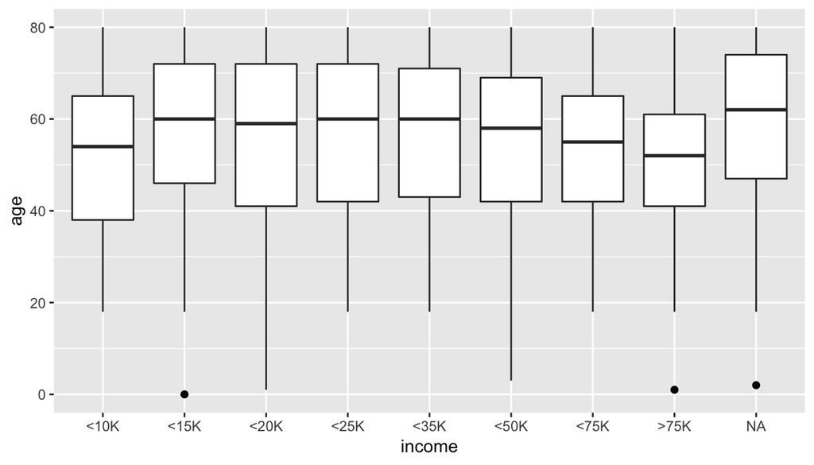

```r
ggplot(data=income_age, aes(x=income, y=age)) +
  geom_boxplot(outlier.colour="black", outlier.shape=16, outlier.size=2, notch=FALSE)
```

##### **Research quesion 2:**

*Find the index values for the desired columns*

```r
grep("smoke100", colnames(brfss2013))
```

```
## [1] 68
```

```r
grep("X_educag", colnames(brfss2013))
```

```
## [1] 263
```

*Create a database with the selected columns*

```r
cols = c(68,263)
smoking_education <- brfss2013[,cols,drop=FALSE]
```

*Create Mosaic comparing smoking with the highest education one completed*

[figure not shown]

```r
ggplot(data=smoking_education) +
  geom_mosaic(aes(x=product(X_educag, smoke100), fill=X_educag), na.rm=TRUE) +
  labs(x="values", title="name of graph")
```

*What are the percentages*

```r
table(smoking_education$X_educag)/nrow(smoking_education)
```

```
##
##               Did not graduate high school
##                                 0.08583804
##                      Graduated high school
##                                 0.29071832
##       Attended college or technical school
##                                 0.27288089
## Graduated from college or technical school
##                                 0.34592649
```

##### **Research quesion 3:**

*Find the index values for the columns I wish to analysis*

```r
grep("vegetab1", colnames(brfss2013))
```

```
## [1] 82
```

```r
grep("fruit1", colnames(brfss2013))
```

```
## [1] 78
```

*Create a data frame with just the vegetables and fruit columns*

```r
cols = c(82,78)
fruits_and_vegetables <- brfss2013[,cols, drop=FALSE]
```

*Create columns with mutated values that represent the number of monthy fruits and vegetables, approximate the number of weekly fruits and vegetables by mulitplying the value by 4 (4 weeks a month), and approximate the number of daily fruits and vegetables by mulitplying the daily value by 30 (30 days in a month)*

```r
fruits_and_vegetables <- fruits_and_vegetables %>%
  mutate(veg_month = ifelse(vegetab1<=399 & vegetab1 >=301, (vegetab1 - 300), ifelse(vegetab1<=299 & vegetab1>=201,(vegetab1-200)*4, ifelse(vegetab1<=199 & vegetab1>=101,(vegetab1-100)*30, 0)))) %>%
   mutate(fruit_month = ifelse(fruit1<=399 & fruit1 >=301, (fruit1 - 300), ifelse(fruit1<=299 & fruit1>=201,(fruit1-200)*4, ifelse(fruit1<=199 & fruit1>=101,(fruit1-100)*30, 0))))
```

*Lets look at the mean, median, sd, and max for the new monthly values*

```r
fruits_and_vegetables %>%
  summarise(mean_fruits = mean(fruit_month, na.rm=TRUE), median_fruits = median(fruit_month, na.rm=TRUE), sd_fruits = sd(fruit_month, na.rm=TRUE), max_fruits = max(fruit_month, na.rm=TRUE))
```

```
##   mean_fruits median_fruits sd_fruits max_fruits
## 1    30.28846            30  33.76809       2970
```

```r
fruits_and_vegetables %>%
  summarise(mean_veg = mean(veg_month, na.rm=TRUE), median_veg = median(veg_month, na.rm=TRUE), sd_veg = sd(veg_month, na.rm=TRUE), max_veg = max(veg_month, na.rm=TRUE))
```

```
##   mean_veg median_veg   sd_veg max_veg
## 1 23.85837         20 23.68094    2970
```

*Since I don’t think its possible to eat 2,970 of either frutis or vegetables we will look to remove some of the outliers. First lets use a skatter plot to view how the data is distributed, and check out the pearson correlation*

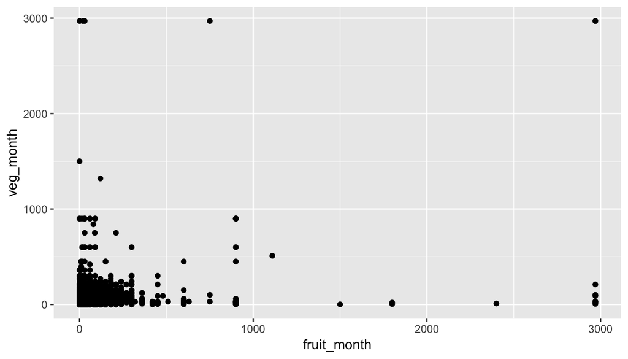

```r
 ggplot(data=fruits_and_vegetables, aes(x=fruit_month, y=veg_month, na.rm=TRUE)) +
   geom_point()
```

```r
 cor(x=fruits_and_vegetables$fruit_month, y=fruits_and_vegetables$veg_month, method="pearson", use = "complete.obs" )
```

```
## [1] 0.2962249
```

```r
 fruits_and_vegetables <- fruits_and_vegetables %>%
   mutate(fruit_month_ = ifelse(fruit_month<91, fruit_month, NA)) %>%
   mutate(veg_month_ = ifelse(veg_month<72, veg_month, NA))
```

*Lets plot these new values and check out their correlation*

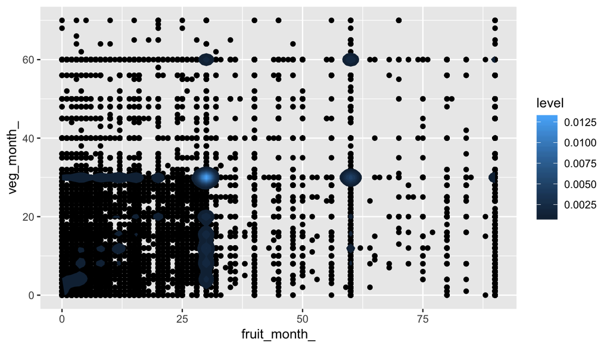

```r
 fruits_and_veggies_plot <- ggplot(data=fruits_and_vegetables, aes(x=fruit_month_, y=veg_month_, na.rm=TRUE)) +
   geom_point()
 fruits_and_veggies_plot + stat_density_2d(aes(fill = ..level..), geom="polygon")
```

```r
 cor(x=fruits_and_vegetables$fruit_month_, y=fruits_and_vegetables$veg_month_, method="pearson", use="complete.obs")
```

```
## [1] 0.2926743
```